# SNP clinality

Thu May 18 02:56:50 2017

*From Evan:* We have 3 files designated HIGH/MODERATE/LOW that are lists of numbers. These numbers correspond to the SNP numbers (so 1 corresponds to the first row of data in the counts file). The numbers in the HIGH file were categorized as high impact, so stuff like premature stop codons and stuff. Details are in the [snpEff manual](http://snpeff.sourceforge.net/SnpEff_manual.html). There's more information that I can pull for each SNP, like what exactly the effect is and if it's in UTR/coding etc...

Here are how many we have in each category:

```r
table(effect)
```

```
## effect
##     none      low moderate     high
##  4951495    30251    17494      760
```

We will look at, by SNP category:

0. Coverage
1. Mean realized homozygosity (probability that two alleles from the same individual agree)
2. Mean outcrossing homozygosity (probability that two alleles from different individuals differ, as a function of distance)
3. Joint regional allele frequncy distribution (joint distribution of 'sample allele frequency', mean number of alleles obtained after choosing one allele per individual, with the set of SNPs fixed)

# Coverage

First let's check that everything looks reasonable and pick some coverage cutoffs. Here are total coverage histograms by type:

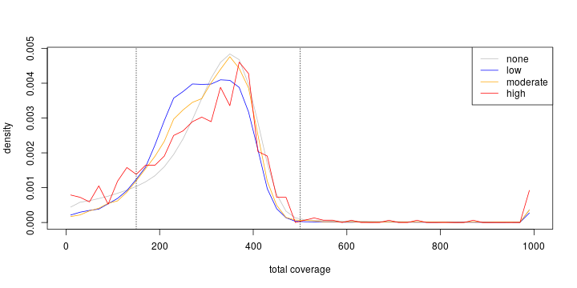

```r
all_hist <- hist(pos$totDepth[pos$totDepth<=1000], plot=FALSE, breaks=50)
depth_hists <- tapply(pmin(1000,pos$totDepth), effect, hist, breaks=all_hist$breaks, plot=FALSE)

plot(0, type='n', xlim=range(all_hist$breaks), ylim=range(lapply(depth_hists, "[[", "density")),
     xlab="total coverage", ylab="density")
for (k in seq_along(depth_hists)) {
    lines(depth_hists[[k]]$mids, depth_hists[[k]]$density, col=effect_cols[k])
}
legend("topright", legend=levels(effect), lty=1, col=effect_cols)
abline(v=c(min_coverage, max_coverage), lty=3)
```

We'll restrict to sites with total coverage between 150 and 500 (the vertical lines in the previous plot). Within these bounds, do the different catgories have statistically significantly different mean total coverages?

```r
good_snps <-  with(pos, totDepth > min_coverage & totDepth < max_coverage)
summary(lm(pos$totDepth ~ effect, subset=good_snps))
```

```
##
## Call:
## lm(formula = pos$totDepth ~ effect, subset = good_snps)
##
## Residuals:
##      Min       1Q   Median       3Q      Max
## -171.064  -48.064    7.936   53.936  199.294
##
## Coefficients:
##                 Estimate Std. Error  t value Pr(>|t|)
## (Intercept)    322.06355    0.03459 9309.649   <2e-16 ***
## effectlow      -22.35732    0.43449  -51.456   <2e-16 ***
## effectmoderate -13.18378    0.57041  -23.113   <2e-16 ***
## effecthigh      -5.99337    2.87054   -2.088   0.0368 *
## ---
## Signif. codes:  0 '***' 0.001 '**' 0.01 '*' 0.05 '.' 0.1 ' ' 1
##
## Residual standard error: 71.87 on 4360444 degrees of freedom
## Multiple R-squared:  0.0007275,  Adjusted R-squared:  0.0007268
## F-statistic:  1058 on 3 and 4360444 DF,  p-value: < 2.2e-16
```

Yes - SNPs with an effect have lower coverage, but the difference *decreases* with SNP effect. This looks to be due to a bimodality in total coverage, with decreasing contributions of the lower mode to larger effect SNPs.

**To-do:** get actual scaffold lengths.

Here are mean coverages by scaffold:

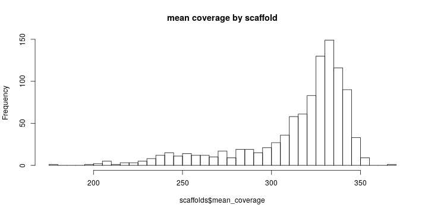

```r
hist(scaffolds$mean_coverage, breaks=50, main='mean coverage by scaffold')
```

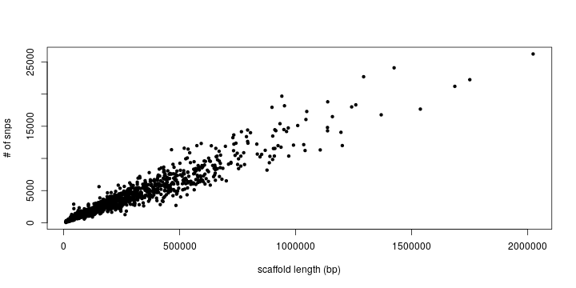

```r
plot(scaffolds$length, scaffolds$nsnps, pch=20, xlab='scaffold length (bp)', ylab='# of snps')
```

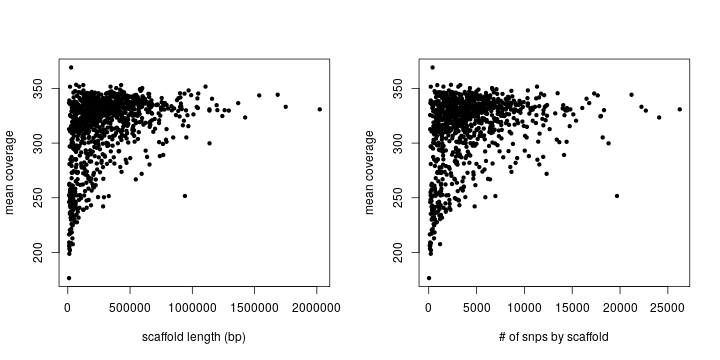

```r
layout(t(1:2))
plot(scaffolds$length, scaffolds$mean_coverage, pch=20, xlab='scaffold length (bp)',
     ylab='mean coverage')
plot(scaffolds$nsnps, scaffolds$mean_coverage, pch=20, xlab='# of snps by scaffold',
     ylab='mean coverage')
```

This range is **much** higher than expected due to chance.

And, here is a plot of mean coverage along the genome:

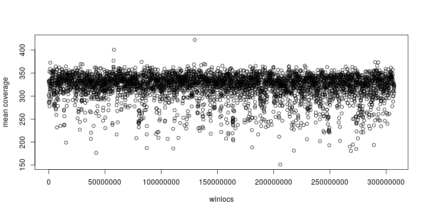

```r
alg_win( pos$totDepth[good_snps], window=1e5, subset=good_snps, ylab='mean coverage')
```

To get coverages by individual and by scaffold, we've used

```
../count-utils/get-coverage-by-scaffold.R 272torts_snp1e6_minmapq20minq30_map2kenro10K.counts.bin.gz 150 500 272torts_snp1e6_minmapq20minq30_map2kenro10K.coverage_by_scaffold.gz
```

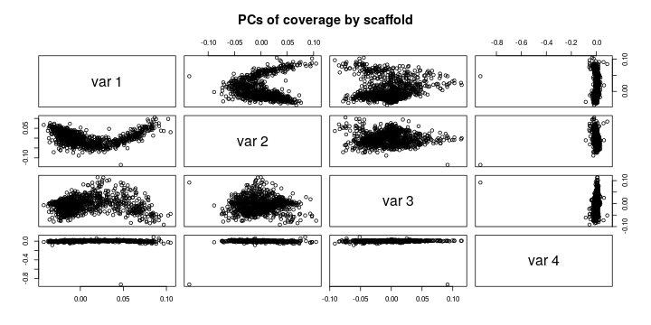

```r
rel_scaf_coverage <- sweep(scaf_coverage, 2, indiv_mean_coverage, "/")
# this is the SAME THING as scaffolds$mean_coverage
# scaffolds$relative_coverage <- rowMeans(scaf_coverage)

coverage_cov <- cov(t(rel_scaf_coverage))
scaf_pcs <- eigen(coverage_cov)

pairs(scaf_pcs$vectors[,1:4], main="PCs of coverage by scaffold")
```

```r
head(scaf_pcs$values)
```

```
## [1] 5.51964640 0.66130709 0.49499394 0.14849332 0.13136233 0.09366259
```

In this plot, there is one line per individual, and the x-axis gives the scaffolds, ordered by PC1.

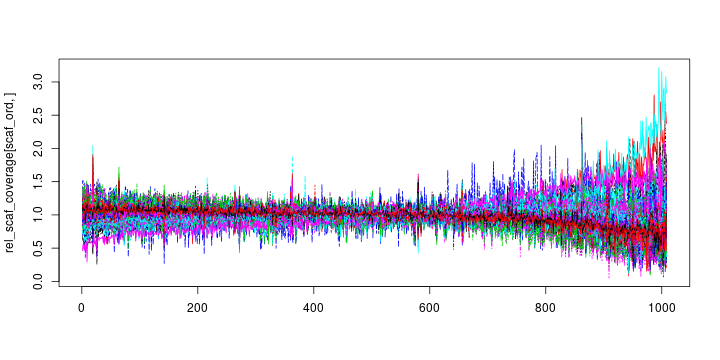

```r
scaf_ord <- order(scaf_pcs$vectors[,1])
matplot(rel_scaf_coverage[scaf_ord,], type='l')
```

Which individuals are showing different patterns? We measure this by taking the correlation of an individual's coverage pattern with the scaffold PC1:

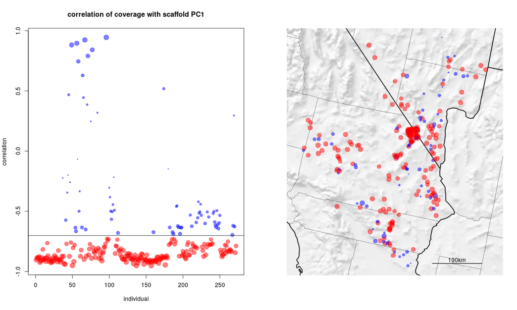

```r
indivs$scafPC <- as.vector(cor(scaf_pcs$vectors[,1], rel_scaf_coverage))
scaf_cor_cutoff <- -0.7
# scaf_cor_colors <- rgb(colorRamp(brewer.pal(name='RdYlBu',n=3),alpha=1.0)((1+indivs$scafPC)/2)/255)
scaf_cor_colors <- adjustcolor(ifelse(indivs$scafPC>scaf_cor_cutoff,'blue','red'),0.5)
scaf_cor_cex <- pmax(0.5,3*abs(indivs$scafPC))

layout(t(1:2))
plot(indivs$scafPC, xlab='individual', ylab='correlation',
     col=scaf_cor_colors, cex=scaf_cor_cex, pch=20,
     main='correlation of coverage with scaffold PC1')
abline(h=scaf_cor_cutoff)
pshade()
points(tort.coords, pch=20,
       cex=scaf_cor_cex,
       col=scaf_cor_colors)
```

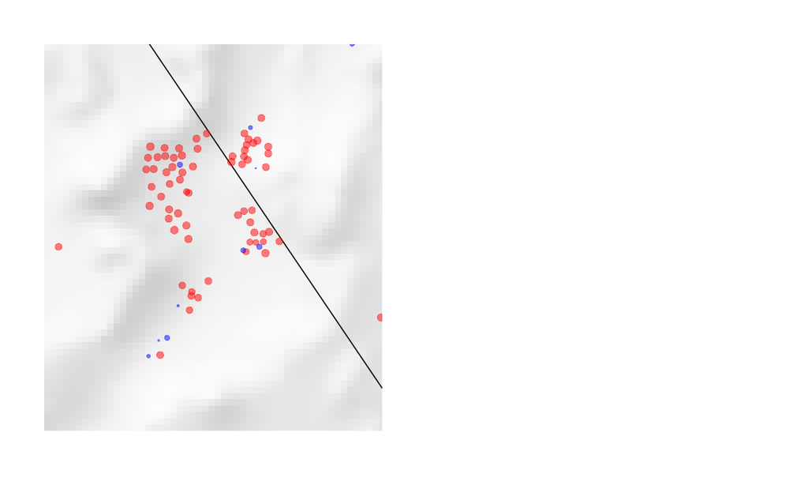

```r
pshade(xlim=.ivanpah.bbox["Easting",], ylim=.ivanpah.bbox["Northing",])
points(tort.coords, pch=20,
       cex=scaf_cor_cex,
       col=scaf_cor_colors)
```

Let's look at some of these wierd scaffolds. Here is coverage on the top few, plotted in a few different ways:

```r
scaffolds[head(order(scaf_pcs$vectors[,1], decreasing=TRUE)),]
```

```
##              name start   end length nsnps mean_coverage
## 997 scaffold_1086    69 16840  16771   287      261.1777
## 104  scaffold_115    37 16919  16882   192      255.0156
## 348  scaffold_376     5 21475  21470   420      241.2643
## 561  scaffold_607    18 22960  22942   264      247.1553
## 992 scaffold_1080    81 47198  47117   538      239.7751
## 578  scaffold_626     4 10202  10198   118      216.4746
```

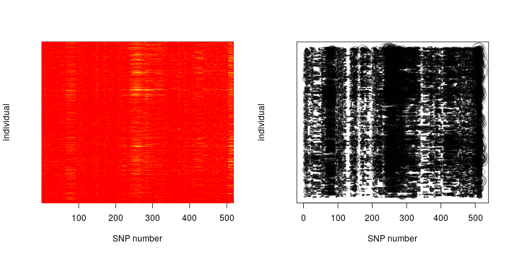

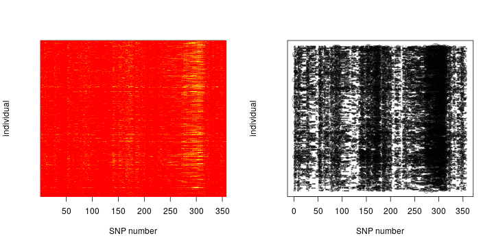

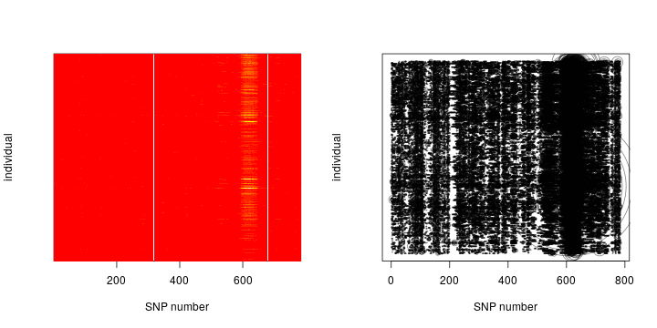

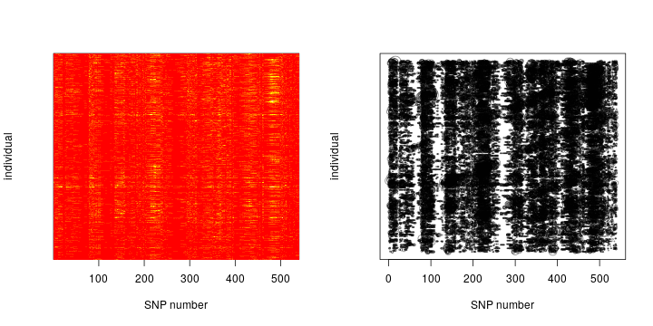

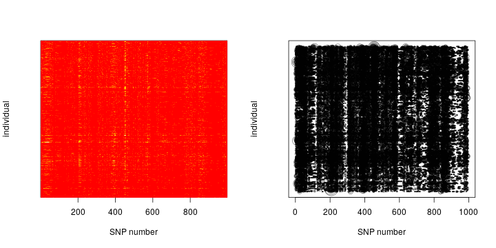

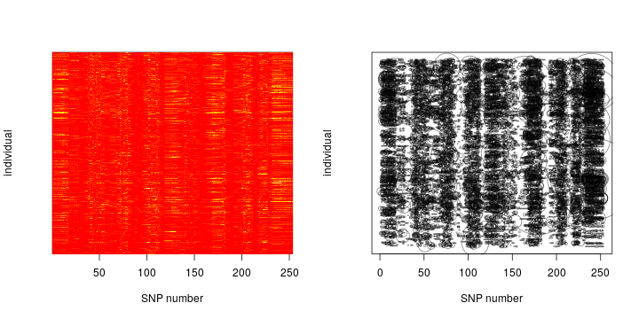

```r
scaf_to_coverage <- function (x) {
    As <- which(1:ncol(x) %% 4 == 1)
    out <- x[,As]
    for (k in 1:3) { out <- out + x[,As+k] }
    return(out)
}
get_coverage <- function (scafname) {
    scaf_to_coverage(as.matrix(read.table(pipe(sprintf("../count-utils/get-scaffold.R %s %s", bincountfile, scafname)))))
}
show_scaf <- function (this_coverage) {
    image(1:nrow(this_coverage), z=this_coverage, xlab='SNP number', ylab='individual', yaxt='n')
    plot(row(this_coverage), col(this_coverage), cex=this_coverage/colMeans(this_coverage)/10, col=adjustcolor('black',0.5), xlab='SNP number', ylab='individual', yaxt='n')
    invisible(this_coverage)
}
scafs <- lapply(scaffolds$name[head(order(scaf_pcs$vectors[,1], decreasing=TRUE))], get_coverage)
layout(t(1:2))
for (ts in scafs) { show_scaf(ts) }
```

Here's some scaffolds from the middle of the pack, for comparison:

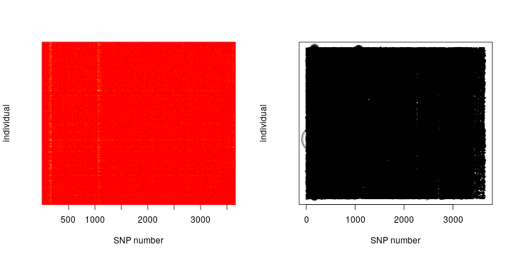

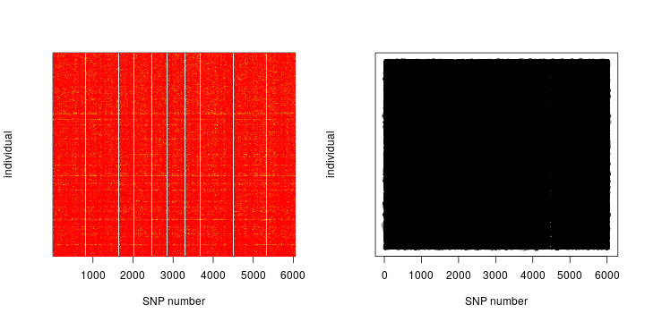

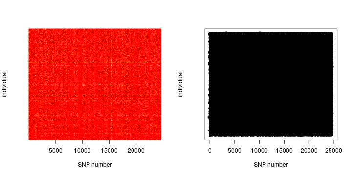

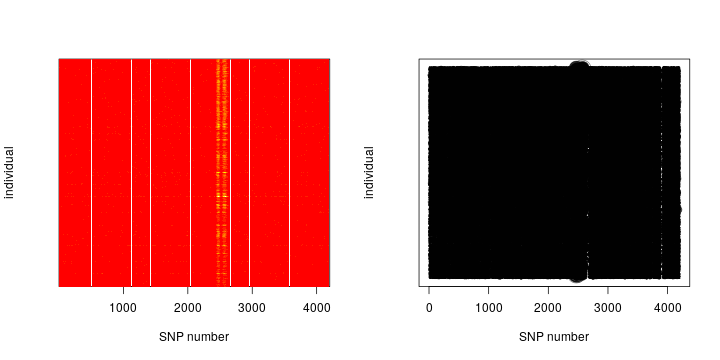

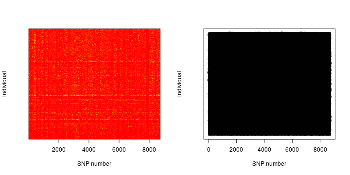

```r
mid_scafs <- lapply(scaffolds$name[order(scaf_pcs$vectors[,1], decreasing=TRUE)[500:504]], get_coverage)
layout(t(1:2))
for (ts in mid_scafs) { show_scaf(ts) }
```